# Part I - Baywheels Data Exploration

## by (Odafe-Ighele Jesse)

## Introduction

> The dataset is basically the data provided for the first 3 months of the year 2022,it contains a combined total of 529086 rides

## Preliminary Wrangling

```python
# import all packages and set plots to be embedded inline
import numpy as np
import pandas as pd
import matplotlib.pyplot as plt
import seaborn as sb
import requests as re
import zipfile,io

%matplotlib inline
```

# GATHERING DATA

This data set includes information about individual rides made using Baywheels in San Fransisco in the first 3 months of 2022. this data was downloaded from https://s3.amazonaws.com/baywheels-data/index.html and multiple data files needed to be joined together to get a single dataset that requires some wrangling to make the data neat enough for analysis.

## Getting 2022(first 3 months) Baywheels data zip file

```python
# defining a function to get the csv file
def get_file(month,year=2022):
    r=re.get(f'https://s3.amazonaws.com/baywheels-data/{year}{month}-baywheels-tripdata.csv.zip')
    z = zipfile.ZipFile(io.BytesIO(r.content))
    csv=z.open(f'{year}{month}-baywheels-tripdata.csv')

    df=pd.read_csv(csv)
    df.to_csv(f'Baywheels{month}-{year}.csv',index = False)
```

```python
get_file('01')
df1 = pd.read_csv('Baywheels01-2022.csv')
df1.head()
```

|  | ride_id | rideable_type | started_at | ended_at | start_station_name | start_station_id | end_station_name | end_station_id | start_lat | start_lng | end_lat | end_lng | member_casual |
| --- | --- | --- | --- | --- | --- | --- | --- | --- | --- | --- | --- | --- | --- |
| 0 | 0DD008BC62836D27 | classic_bike | 2022-01-13 19:12:23 | 2022-01-13 19:22:13 | Washington St at Van Ness Ave | SF-E22 | Natoma St at New Montgomery St | SF-G28-2 | 37.792980 | -122.423302 | 37.786456 | -122.399749 | member |
| 1 | BE9F5C77F1BE0FBF | classic_bike | 2022-01-15 15:58:55 | 2022-01-15 16:10:03 | Washington St at Van Ness Ave | SF-E22 | Natoma St at New Montgomery St | SF-G28-2 | 37.792980 | -122.423302 | 37.786456 | -122.399749 | member |
| 2 | F0826402062D5A44 | classic_bike | 2022-01-07 20:34:47 | 2022-01-07 20:55:25 | 17th St at Dolores St | SF-N21 | Scott St at Golden Gate Ave | SF-I19 | 37.763015 | -122.426497 | 37.778999 | -122.436861 | member |
| 3 | EE9A8BB189061CFD | classic_bike | 2022-01-31 16:38:25 | 2022-01-31 17:13:05 | El Embarcadero at Grand Ave | OK-I9 | Ninth St at Heinz Ave | BK-H3 | 37.808715 | -122.249251 | 37.853907 | -122.289698 | member |
| 4 | 772A8B545A8525C0 | classic_bike | 2022-01-28 17:28:22 | 2022-01-28 17:39:55 | 17th St at Dolores St | SF-N21 | Octavia Blvd at Page St | SF-J22-1 | 37.763015 | -122.426497 | 37.774018 | -122.423809 | casual |

```python
get_file('02')
df2 = pd.read_csv('Baywheels02-2022.csv')
df2.head()
```

|  | ride_id | rideable_type | started_at | ended_at | start_station_name | start_station_id | end_station_name | end_station_id | start_lat | start_lng | end_lat | end_lng | member_casual |
| --- | --- | --- | --- | --- | --- | --- | --- | --- | --- | --- | --- | --- | --- |
| 0 | 7DE9183F08BF920B | electric_bike | 2022-02-15 17:16:18 | 2022-02-15 17:48:17 | Washington St at Van Ness Ave | SF-E22 | Washington St at Van Ness Ave | SF-E22 | 37.793075 | -122.423316 | 37.792980 | -122.423302 | casual |
| 1 | 7905F466BC27CF7C | electric_bike | 2022-02-10 12:30:55 | 2022-02-10 13:04:22 | Eucalyptus Dr at 20th Ave | SF-W8 | Eucalyptus Dr at 20th Ave | SF-W8 | 37.731061 | -122.476393 | 37.731085 | -122.476163 | casual |
| 2 | 93F8D5AEC877944F | electric_bike | 2022-02-14 12:05:07 | 2022-02-14 12:10:24 | Washington St at Van Ness Ave | SF-E22 | Washington St at Van Ness Ave | SF-E22 | 37.792865 | -122.423305 | 37.792980 | -122.423302 | casual |
| 3 | AF6201B45FE30E74 | electric_bike | 2022-02-01 09:32:10 | 2022-02-01 09:33:58 | Bryant St at 6th St | SF-J27 | Bryant St at 6th St | SF-J27 | 37.775765 | -122.402732 | 37.775838 | -122.402694 | member |
| 4 | 2F7E6F911D4D4BEE | electric_bike | 2022-02-24 14:56:49 | 2022-02-24 15:16:28 | Bryant St at 6th St | SF-J27 | Bryant St at 6th St | SF-J27 | 37.775852 | -122.402681 | 37.775838 | -122.402694 | casual |

```python
get_file('03')
df3 = pd.read_csv('Baywheels03-2022.csv')
df3.head()
```

|  | ride_id | rideable_type | started_at | ended_at | start_station_name | start_station_id | end_station_name | end_station_id | start_lat | start_lng | end_lat | end_lng | member_casual |
| --- | --- | --- | --- | --- | --- | --- | --- | --- | --- | --- | --- | --- | --- |
| 0 | 2CD48636BE2CAFE3 | classic_bike | 2022-03-16 01:00:47 | 2022-03-16 01:04:28 | Haste St at Telegraph Ave | BK-E9-2 | Ellsworth St at Russell St | BK-G8 | 37.866043 | -122.258804 | 37.857490 | -122.261578 | member |
| 1 | C6246A9BB6BECB42 | electric_bike | 2022-03-07 17:12:30 | 2022-03-07 17:22:20 | Arguello Blvd at Edward St | SF-H13 | Page St at Scott St | SF-K19 | 37.778539 | -122.458656 | 37.772354 | -122.435857 | member |
| 2 | F87E69D1F1B82EF9 | electric_bike | 2022-03-08 17:06:33 | 2022-03-08 17:14:57 | Esprit Park | SF-O30 | Bryant St at 6th St | SF-J27 | 37.761655 | -122.390756 | 37.775838 | -122.402694 | member |
| 3 | 1A299A41AD3C35E5 | electric_bike | 2022-03-29 08:15:44 | 2022-03-29 08:22:07 | Esprit Park | SF-O30 | Brannan St at Harriet St | SF-J27 | 37.761629 | -122.390741 | 37.774331 | -122.401706 | casual |
| 4 | FDF5B9B7241676EE | classic_bike | 2022-03-07 15:22:26 | 2022-03-07 16:14:10 | Haste St at Telegraph Ave | BK-E9-2 | University Ave at Oxford St | BK-C8 | 37.866043 | -122.258804 | 37.872355 | -122.266447 | member |

# ACCESSING THE DATA

## df1

```python
# Checking the name of the columns
df1.columns
```

```
Index(['ride_id', 'rideable_type', 'started_at', 'ended_at',
       'start_station_name', 'start_station_id', 'end_station_name',
       'end_station_id', 'start_lat', 'start_lng', 'end_lat', 'end_lng',
       'member_casual'],
      dtype='object')
```

```python
# Checking the contents of the member_casual column
df1.member_casual.value_counts()
```

```
member    84247
casual    66979
Name: member_casual, dtype: int64
```

```python
# Checking the datatypes and number of entries
df1.info()
```

```
<class 'pandas.core.frame.DataFrame'>
RangeIndex: 151226 entries, 0 to 151225
Data columns (total 13 columns):
 #   Column              Non-Null Count   Dtype
---  ------              --------------   -----
 0   ride_id             151226 non-null  object
 1   rideable_type       151226 non-null  object
 2   started_at          151226 non-null  object
 3   ended_at            151226 non-null  object
 4   start_station_name  124493 non-null  object
 5   start_station_id    124493 non-null  object
 6   end_station_name    120780 non-null  object
 7   end_station_id      120780 non-null  object
 8   start_lat           151226 non-null  float64
 9   start_lng           151226 non-null  float64
 10  end_lat             151051 non-null  float64
 11  end_lng             151051 non-null  float64
 12  member_casual       151226 non-null  object
dtypes: float64(4), object(9)
memory usage: 15.0+ MB
```

```python
# Checking for null values
df1.isna().sum()
```

```
ride_id                   0
rideable_type             0
started_at                0
ended_at                  0
start_station_name    26733
start_station_id      26733
end_station_name      30446
end_station_id        30446
start_lat                 0
start_lng                 0
end_lat                 175
end_lng                 175
member_casual             0
dtype: int64
```

```python
# Checking the mathematical statistics summary
df1.describe()
```

|  | start_lat | start_lng | end_lat | end_lng |
| --- | --- | --- | --- | --- |
| count | 151226.000000 | 151226.000000 | 151051.000000 | 151051.000000 |
| mean | 37.760120 | -122.386625 | 37.760266 | -122.386584 |
| std | 0.094742 | 0.115762 | 0.094679 | 0.115621 |
| min | 37.260000 | -122.511271 | 37.260000 | -122.511208 |
| 25% | 37.765328 | -122.429125 | 37.765429 | -122.426964 |
| 50% | 37.776311 | -122.412571 | 37.776311 | -122.411738 |
| 75% | 37.788644 | -122.397543 | 37.789620 | -122.397437 |
| max | 37.880222 | -121.800000 | 37.880222 | -121.800000 |

```python
# Checking for duplicates
df1.duplicated().sum()
```

```
0
```

## df2

```python
# Checking the name of the columns
df2.columns
```

```
Index(['ride_id', 'rideable_type', 'started_at', 'ended_at',
       'start_station_name', 'start_station_id', 'end_station_name',
       'end_station_id', 'start_lat', 'start_lng', 'end_lat', 'end_lng',
       'member_casual'],
      dtype='object')
```

```python
# Checking the mathematical statistics summary
df2.describe()
```

|  | start_lat | start_lng | end_lat | end_lng |
| --- | --- | --- | --- | --- |
| count | 172851.000000 | 172851.000000 | 172659.000000 | 172659.000000 |
| mean | 37.760947 | -122.385400 | 37.761083 | -122.385294 |
| std | 0.094990 | 0.115872 | 0.094868 | 0.115600 |
| min | 37.240000 | -122.511268 | 37.240000 | -122.520000 |
| 25% | 37.765794 | -122.427063 | 37.765429 | -122.426614 |
| 50% | 37.776513 | -122.411741 | 37.776619 | -122.411536 |
| 75% | 37.789620 | -122.395626 | 37.790000 | -122.394989 |
| max | 37.880222 | -121.800000 | 37.880222 | -121.800000 |

```python
# Checking for duplicates
df2.duplicated().sum()
```

```
0
```

```python
# Checking the datatypes and number of entries
df2.info()
```

```
<class 'pandas.core.frame.DataFrame'>
RangeIndex: 172851 entries, 0 to 172850
Data columns (total 13 columns):
 #   Column              Non-Null Count   Dtype
---  ------              --------------   -----
 0   ride_id             172851 non-null  object
 1   rideable_type       172851 non-null  object
 2   started_at          172851 non-null  object
 3   ended_at            172851 non-null  object
 4   start_station_name  144896 non-null  object
 5   start_station_id    144896 non-null  object
 6   end_station_name    141000 non-null  object
 7   end_station_id      141000 non-null  object
 8   start_lat           172851 non-null  float64
 9   start_lng           172851 non-null  float64
 10  end_lat             172659 non-null  float64
 11  end_lng             172659 non-null  float64
 12  member_casual       172851 non-null  object
dtypes: float64(4), object(9)
memory usage: 17.1+ MB
```

```python
# Checking for null values
df2.isna().sum()
```

```
ride_id                   0
rideable_type             0
started_at                0
ended_at                  0
start_station_name    27955
start_station_id      27955
end_station_name      31851
end_station_id        31851
start_lat                 0
start_lng                 0
end_lat                 192
end_lng                 192
member_casual             0
dtype: int64
```

## df3

```python
# Checking the name of the columns
df3.columns
```

```
Index(['ride_id', 'rideable_type', 'started_at', 'ended_at',
       'start_station_name', 'start_station_id', 'end_station_name',
       'end_station_id', 'start_lat', 'start_lng', 'end_lat', 'end_lng',
       'member_casual'],
      dtype='object')
```

```python
# Checking the mathematical statistics summary
df3.describe()
```

|  | start_lat | start_lng | end_lat | end_lng |
| --- | --- | --- | --- | --- |
| count | 205009.000000 | 205009.000000 | 204795.000000 | 204795.000000 |
| mean | 37.761377 | -122.385331 | 37.761562 | -122.385081 |
| std | 0.094118 | 0.114498 | 0.093949 | 0.114216 |
| min | 37.240000 | -122.511261 | 37.240000 | -122.520000 |
| 25% | 37.766164 | -122.426676 | 37.766100 | -122.426203 |
| 50% | 37.776664 | -122.411422 | 37.776619 | -122.410807 |
| 75% | 37.790000 | -122.395282 | 37.790000 | -122.394989 |
| max | 37.880222 | -121.790000 | 37.900000 | -121.790000 |

```python
# Checking for duplicates
df3.duplicated().sum()
```

```
0
```

```python
# Checking the datatypes and number of entries
df3.info()
```

```
<class 'pandas.core.frame.DataFrame'>
RangeIndex: 205009 entries, 0 to 205008
Data columns (total 13 columns):
 #   Column              Non-Null Count   Dtype
---  ------              --------------   -----
 0   ride_id             205009 non-null  object
 1   rideable_type       205009 non-null  object
 2   started_at          205009 non-null  object
 3   ended_at            205009 non-null  object
 4   start_station_name  173965 non-null  object
 5   start_station_id    173965 non-null  object
 6   end_station_name    169835 non-null  object
 7   end_station_id      169835 non-null  object
 8   start_lat           205009 non-null  float64
 9   start_lng           205009 non-null  float64
 10  end_lat             204795 non-null  float64
 11  end_lng             204795 non-null  float64
 12  member_casual       205009 non-null  object
dtypes: float64(4), object(9)
memory usage: 20.3+ MB
```

```python
# Checking for null values
df3.isna().sum()
```

```
ride_id                   0
rideable_type             0
started_at                0
ended_at                  0
start_station_name    31044
start_station_id      31044
end_station_name      35174
end_station_id        35174
start_lat                 0
start_lng                 0
end_lat                 214
end_lng                 214
member_casual             0
dtype: int64
```

# OBSERVATIONS

- TIDINESS
  - The df1,df2,df3 datasets column can be further simplified by intorducing new columns
  - Melt the 3 dataframes together
  - Some of the df1,df2,df3 dataset columns can also be dropped
  - Rename some columns
- QUALITY
  - The datatype of some of the columns can be modified
  - Some rows start location and end location are the same giving a wrong start and end time
  - The time can be calculated using the respective start and end date

# CLEANING

```python
# Creating copies of dataframes
clean_df1= df1.copy()
clean_df2=df2.copy()
clean_df3=df3.copy()
```

### Addition of new columns

### Define

Adding month column to the 3 dataframes to ease the merging of the 3 dataframes

### Code

```python
# Creating new columns
clean_df1['month']='January'
clean_df2['month']='February'
clean_df3['month']= 'March'
```

### Test

```python
clean_df1.columns
```

```
Index(['ride_id', 'rideable_type', 'started_at', 'ended_at',
       'start_station_name', 'start_station_id', 'end_station_name',
       'end_station_id', 'start_lat', 'start_lng', 'end_lat', 'end_lng',
       'member_casual', 'month'],
      dtype='object')
```

### Append the 3 dataframes together

### Define

Appending the 3 dataframes together

### Code

```python
# Save the 3 files to csv
clean_df1.to_csv('clean_Jan.csv',index=False)
clean_df2.to_csv('clean_Feb.csv',index=False)
clean_df3.to_csv('clean_Mar.csv',index=False)
clean_df1.to_csv('Baywheels_ 2022.csv',index=False)
# Create a for loop to append the dataframes
files=['clean_Feb.csv','clean_Mar.csv']

df_2022=pd.read_csv('Baywheels_ 2022.csv')
for file in files:
    df_2022 = df_2022.append(pd.read_csv(file))
```

### Test

```python
df_2022.shape
```

```
(529086, 14)
```

```python
df_2022.info()
```

```
<class 'pandas.core.frame.DataFrame'>
Int64Index: 529086 entries, 0 to 205008
Data columns (total 14 columns):
 #   Column              Non-Null Count   Dtype
---  ------              --------------   -----
 0   ride_id             529086 non-null  object
 1   rideable_type       529086 non-null  object
 2   started_at          529086 non-null  object
 3   ended_at            529086 non-null  object
 4   start_station_name  443354 non-null  object
 5   start_station_id    443354 non-null  object
 6   end_station_name    431615 non-null  object
 7   end_station_id      431615 non-null  object
 8   start_lat           529086 non-null  float64
 9   start_lng           529086 non-null  float64
 10  end_lat             528505 non-null  float64
 11  end_lng             528505 non-null  float64
 12  member_casual       529086 non-null  object
 13  month               529086 non-null  object
dtypes: float64(4), object(10)
memory usage: 60.5+ MB
```

### CREATION OF NEW COLUMNS

### Obtaining the time duration of each ride

### Define

Using the start and end date to get the time duration then converting it to get the duration in minutes,hours and days

### Code

```python
# Converting the started at and ended at columns to datetime datatype
df_2022['started_at'] = pd.to_datetime(df_2022['started_at'])
df_2022['ended_at'] =  pd.to_datetime(df_2022['ended_at'])
(df_2022.ended_at - df_2022.started_at).dt.total_seconds()



# get the seconds for hours + minutes + seconds, but not days
# note the difference from total_seconds
df_2022.insert(1,'duration_in_seconds',(df_2022.ended_at - df_2022.started_at).dt.seconds)
df_2022.insert(2,'duration_in_minutes',df_2022.duration_in_seconds/60)
df_2022.insert(3,'duration_in_hours',df_2022.duration_in_seconds/3600)
```

### Test

```python
df_2022.info()
```

```
<class 'pandas.core.frame.DataFrame'>
Int64Index: 529086 entries, 0 to 205008
Data columns (total 17 columns):
 #   Column               Non-Null Count   Dtype
---  ------               --------------   -----
 0   ride_id              529086 non-null  object
 1   duration_in_seconds  529086 non-null  int64
 2   duration_in_minutes  529086 non-null  float64
 3   duration_in_hours    529086 non-null  float64
 4   rideable_type        529086 non-null  object
 5   started_at           529086 non-null  datetime64[ns]
 6   ended_at             529086 non-null  datetime64[ns]
 7   start_station_name   443354 non-null  object
 8   start_station_id     443354 non-null  object
 9   end_station_name     431615 non-null  object
 10  end_station_id       431615 non-null  object
 11  start_lat            529086 non-null  float64
 12  start_lng            529086 non-null  float64
 13  end_lat              528505 non-null  float64
 14  end_lng              528505 non-null  float64
 15  member_casual        529086 non-null  object
 16  month                529086 non-null  object
dtypes: datetime64[ns](2), float64(6), int64(1), object(8)
memory usage: 72.7+ MB
```

### THE START LOCATION AND END LOCATION ARE THE SAME GIVING UNREALISTIC TIME DURATIONS

### Define

Unrealistic time durations need to be removed e.g 0 seconds,1 second

### Code

```python
# The duration of some rides is 0 and 1 second which isnt realistic
df_2022 = df_2022[df_2022['start_station_name'] != df_2022['end_station_name']]
df_2022['start_lat'] = df_2022['start_lat'].round(2)
df_2022['end_lat'] = df_2022['end_lat'].round(2)
df_2022 = df_2022[df_2022['start_lat'] != df_2022['end_lat']]
df_2022= df_2022.drop(105118)
```

### Test

```python
df_2022.nsmallest(50,'duration_in_seconds')
```

|  | ride_id | duration_in_seconds | duration_in_minutes | duration_in_hours | rideable_type | started_at | ended_at | start_station_name | start_station_id | end_station_name | end_station_id | start_lat | start_lng | end_lat | end_lng | member_casual | month |
| --- | --- | --- | --- | --- | --- | --- | --- | --- | --- | --- | --- | --- | --- | --- | --- | --- | --- |
| 189783 | B25DF42DB72C4AA9 | 12 | 0.200000 | 0.003333 | electric_bike | 2022-03-22 19:29:01 | 2022-03-22 19:29:13 | Jackson Playground | SF-N28 | NaN | NaN | 37.77 | -122.398951 | 37.76 | -122.400000 | member | March |
| 200818 | 227C8EAA601E2FAF | 14 | 0.233333 | 0.003889 | electric_bike | 2022-03-16 13:48:55 | 2022-03-16 13:49:09 | NaN | NaN | NaN | NaN | 37.79 | -122.410000 | 37.78 | -122.410000 | casual | March |
| 198201 | 0B9F299E1DB18992 | 15 | 0.250000 | 0.004167 | electric_bike | 2022-03-13 23:15:44 | 2022-03-13 23:15:59 | NaN | NaN | NaN | NaN | 37.79 | -122.470000 | 37.78 | -122.470000 | casual | March |
| 178517 | F1E048EC9A1BCF7F | 24 | 0.400000 | 0.006667 | electric_bike | 2022-03-03 17:48:03 | 2022-03-03 17:48:27 | 2nd St at Folsom St | SF-H29 | NaN | NaN | 37.79 | -122.396162 | 37.78 | -122.400000 | member | March |
| 115604 | EBF26C8B0CB51CAE | 26 | 0.433333 | 0.007222 | electric_bike | 2022-03-23 17:54:37 | 2022-03-23 17:55:03 | Octavia Blvd at Page St | SF-J22-1 | NaN | NaN | 37.77 | -122.423860 | 37.78 | -122.420000 | member | March |
| 166800 | 90E2071FF3EE5F7E | 29 | 0.483333 | 0.008056 | electric_bike | 2022-02-26 18:26:57 | 2022-02-26 18:27:26 | NaN | NaN | NaN | NaN | 37.80 | -122.400000 | 37.79 | -122.400000 | casual | February |
| 118135 | 347FD8E709207061 | 31 | 0.516667 | 0.008611 | classic_bike | 2022-03-02 17:58:16 | 2022-03-02 17:58:47 | San Francisco Ferry Building (Harry Bridges Pl... | SF-E29-1 | Market St at Steuart St | SF-E29-2 | 37.80 | -122.394203 | 37.79 | -122.394880 | member | March |
| 167680 | 52A832EB1BEB6B24 | 32 | 0.533333 | 0.008889 | electric_bike | 2022-03-10 09:46:03 | 2022-03-10 09:46:35 | NaN | NaN | Clay St at Battery St | SF-E28 | 37.79 | -122.400000 | 37.80 | -122.399970 | member | March |
| 140911 | AFD517C44BFB210E | 33 | 0.550000 | 0.009167 | electric_bike | 2022-01-27 07:08:27 | 2022-01-27 07:09:00 | S Van Ness Ave at Market St | SF-J23-2 | NaN | NaN | 37.77 | -122.419070 | 37.78 | -122.420000 | member | January |
| 118134 | 865ABA85B20A87F6 | 33 | 0.550000 | 0.009167 | classic_bike | 2022-03-02 17:59:58 | 2022-03-02 18:00:31 | San Francisco Ferry Building (Harry Bridges Pl... | SF-E29-1 | Market St at Steuart St | SF-E29-2 | 37.80 | -122.394203 | 37.79 | -122.394880 | member | March |
| 195477 | D9D8D892D750AFB4 | 33 | 0.550000 | 0.009167 | electric_bike | 2022-03-09 09:48:50 | 2022-03-09 09:49:23 | NaN | NaN | NaN | NaN | 37.75 | -122.430000 | 37.76 | -122.430000 | member | March |
| 117354 | 270808F669A7E162 | 34 | 0.566667 | 0.009444 | electric_bike | 2022-03-09 21:04:54 | 2022-03-09 21:05:28 | San Francisco Ferry Building (Harry Bridges Pl... | SF-E29-1 | Market St at Steuart St | SF-E29-2 | 37.80 | -122.394250 | 37.79 | -122.394880 | member | March |
| 146936 | 1B0AFBEF43B3BEF8 | 34 | 0.566667 | 0.009444 | classic_bike | 2022-03-07 21:45:39 | 2022-03-07 21:46:13 | Market St at Steuart St | SF-E29-2 | San Francisco Ferry Building (Harry Bridges Pl... | SF-E29-1 | 37.79 | -122.394880 | 37.80 | -122.394203 | member | March |
| 118133 | 74E17B90A87F88FF | 35 | 0.583333 | 0.009722 | classic_bike | 2022-03-02 18:07:00 | 2022-03-02 18:07:35 | San Francisco Ferry Building (Harry Bridges Pl... | SF-E29-1 | Market St at Steuart St | SF-E29-2 | 37.80 | -122.394203 | 37.79 | -122.394880 | member | March |
| 76162 | 56AAAA8864A7F584 | 37 | 0.616667 | 0.010278 | docked_bike | 2022-03-01 22:56:07 | 2022-03-01 22:56:44 | Market St at Steuart St | SF-E29-2 | San Francisco Ferry Building (Harry Bridges Pl... | SF-E29-1 | 37.79 | -122.394881 | 37.80 | -122.394203 | casual | March |
| 185558 | 6012C146BCE8F1D7 | 39 | 0.650000 | 0.010833 | electric_bike | 2022-03-08 08:35:16 | 2022-03-08 08:35:55 | Hospital St at Mariposa St | SF-N30 | NaN | NaN | 37.76 | -122.390927 | 37.77 | -122.390000 | member | March |
| 194916 | 4888677896D301E5 | 39 | 0.650000 | 0.010833 | electric_bike | 2022-03-18 13:07:15 | 2022-03-18 13:07:54 | NaN | NaN | NaN | NaN | 37.80 | -122.400000 | 37.79 | -122.400000 | casual | March |
| 56804 | B53FC5247F5D7985 | 40 | 0.666667 | 0.011111 | electric_bike | 2022-02-19 22:30:01 | 2022-02-19 22:30:41 | NaN | NaN | Yerba Buena Center for the Arts (Howard St at ... | SF-H27-1 | 37.79 | -122.400000 | 37.78 | -122.400876 | member | February |
| 118136 | B2468B1177A30309 | 40 | 0.666667 | 0.011111 | classic_bike | 2022-03-02 17:55:52 | 2022-03-02 17:56:32 | San Francisco Ferry Building (Harry Bridges Pl... | SF-E29-1 | Market St at Steuart St | SF-E29-2 | 37.80 | -122.394203 | 37.79 | -122.394880 | member | March |
| 81890 | 0765C343D212372C | 41 | 0.683333 | 0.011389 | electric_bike | 2022-02-27 20:56:32 | 2022-02-27 20:57:13 | NaN | NaN | 2nd St at Folsom St | SF-H29 | 37.78 | -122.400000 | 37.79 | -122.396217 | member | February |
| 146912 | 58E8C790E75ACDF6 | 41 | 0.683333 | 0.011389 | electric_bike | 2022-03-30 20:27:33 | 2022-03-30 20:28:14 | Market St at Steuart St | SF-E29-2 | San Francisco Ferry Building (Harry Bridges Pl... | SF-E29-1 | 37.79 | -122.394853 | 37.80 | -122.394203 | member | March |
| 156118 | D23FFFC53FC3ED89 | 42 | 0.700000 | 0.011667 | classic_bike | 2022-02-17 06:55:42 | 2022-02-17 06:56:24 | Market St at Steuart St | SF-E29-2 | San Francisco Ferry Building (Harry Bridges Pl... | SF-E29-1 | 37.79 | -122.394880 | 37.80 | -122.394203 | casual | February |
| 81455 | B9F026C64CBABF99 | 44 | 0.733333 | 0.012222 | electric_bike | 2022-02-04 09:56:22 | 2022-02-04 09:57:06 | NaN | NaN | 2nd St at Folsom St | SF-H29 | 37.78 | -122.400000 | 37.79 | -122.396217 | member | February |
| 59749 | 8FA12D8624DDD913 | 45 | 0.750000 | 0.012500 | electric_bike | 2022-02-05 14:15:17 | 2022-02-05 14:16:02 | Franklin Square | SF-N25 | NaN | NaN | 37.76 | -122.410372 | 37.77 | -122.410000 | member | February |
| 179550 | 76FC3574EE71AA5A | 46 | 0.766667 | 0.012778 | electric_bike | 2022-03-17 21:03:41 | 2022-03-17 21:04:27 | North Point St at Polk St | SF-A22 | NaN | NaN | 37.81 | -122.422911 | 37.80 | -122.420000 | casual | March |
| 128218 | DBF2B1CF44B32F57 | 47 | 0.783333 | 0.013056 | electric_bike | 2022-01-14 02:03:34 | 2022-01-14 02:04:21 | NaN | NaN | 2nd St at Folsom St | SF-H29 | 37.78 | -122.400000 | 37.79 | -122.396217 | casual | January |
| 167020 | C1566F4F84612C34 | 47 | 0.783333 | 0.013056 | classic_bike | 2022-03-24 11:10:30 | 2022-03-24 11:11:17 | Jackson Playground | SF-N28 | Hubbell St at 16th St | SF-M28 | 37.76 | -122.399025 | 37.77 | -122.398198 | member | March |
| 100732 | 5AD86A4B761898AC | 48 | 0.800000 | 0.013333 | electric_bike | 2022-02-19 00:57:41 | 2022-02-19 00:58:29 | San Francisco Ferry Building (Harry Bridges Pl... | SF-E29-1 | Market St at Steuart St | SF-E29-2 | 37.80 | -122.394198 | 37.79 | -122.394880 | member | February |
| 15108 | FA859FE3D44063AC | 49 | 0.816667 | 0.013611 | classic_bike | 2022-01-19 17:06:36 | 2022-01-19 17:07:25 | San Francisco Ferry Building (Harry Bridges Pl... | SF-E29-1 | Market St at Steuart St | SF-E29-2 | 37.80 | -122.394203 | 37.79 | -122.394880 | member | January |
| 100710 | C38DC4A05965F8D9 | 49 | 0.816667 | 0.013611 | classic_bike | 2022-02-27 12:26:34 | 2022-02-27 12:27:23 | San Francisco Ferry Building (Harry Bridges Pl... | SF-E29-1 | Market St at Steuart St | SF-E29-2 | 37.80 | -122.394203 | 37.79 | -122.394880 | member | February |
| 172522 | 24F483C3DB7013E5 | 49 | 0.816667 | 0.013611 | electric_bike | 2022-02-19 21:30:14 | 2022-02-19 21:31:03 | NaN | NaN | NaN | NaN | 37.34 | -121.890000 | 37.33 | -121.890000 | member | February |
| 173431 | 2BC1D9B9EA4738FA | 49 | 0.816667 | 0.013611 | electric_bike | 2022-03-05 01:55:08 | 2022-03-05 01:55:57 | 16th St Mission BART Station 2 | SF-N22-1B | NaN | NaN | 37.76 | -122.420173 | 37.77 | -122.420000 | casual | March |
| 143185 | C09250983D3E502D | 51 | 0.850000 | 0.014167 | electric_bike | 2022-02-05 20:19:41 | 2022-02-05 20:20:32 | NaN | NaN | NaN | NaN | 37.34 | -121.890000 | 37.33 | -121.890000 | member | February |
| 139717 | 5089BEBCE9C70D88 | 52 | 0.866667 | 0.014444 | electric_bike | 2022-02-23 16:06:30 | 2022-02-23 16:07:22 | NaN | NaN | NaN | NaN | 37.80 | -122.410000 | 37.81 | -122.410000 | casual | February |
| 69396 | 2CFDB5AB55D29464 | 54 | 0.900000 | 0.015000 | electric_bike | 2022-01-12 14:05:23 | 2022-01-12 14:06:17 | Valencia St at 24th St | SF-Q22-2 | Valencia St at 22nd St | SF-Q22-1 | 37.75 | -122.420727 | 37.76 | -122.420975 | member | January |
| 155064 | 6B716C09C3897915 | 54 | 0.900000 | 0.015000 | classic_bike | 2022-02-25 18:13:51 | 2022-02-25 18:14:45 | Market St at Steuart St | SF-E29-2 | San Francisco Ferry Building (Harry Bridges Pl... | SF-E29-1 | 37.79 | -122.394880 | 37.80 | -122.394203 | member | February |
| 50061 | B3153A8DEEA457B0 | 55 | 0.916667 | 0.015278 | electric_bike | 2022-03-28 18:17:00 | 2022-03-28 18:17:55 | Franklin Square | SF-N25 | Bryant St at 15th St | SF-M25 | 37.76 | -122.410369 | 37.77 | -122.410662 | member | March |
| 73368 | 94B721E716341D9F | 56 | 0.933333 | 0.015556 | classic_bike | 2022-02-12 23:42:28 | 2022-02-12 23:43:24 | Cyril Magnin St at Ellis St | SF-G26 | Powell St BART Station (Market St at 5th St) | SF-H26 | 37.79 | -122.408923 | 37.78 | -122.408445 | member | February |
| 8956 | 98E910A3AFF185BC | 57 | 0.950000 | 0.015833 | electric_bike | 2022-01-31 19:37:01 | 2022-01-31 19:37:58 | 17th & Folsom Street Park (17th St at Folsom St) | SF-N23 | NaN | NaN | 37.76 | -122.415440 | 37.77 | -122.420000 | casual | January |
| 29089 | A0436388DDD379BE | 57 | 0.950000 | 0.015833 | classic_bike | 2022-01-11 17:26:26 | 2022-01-11 17:27:23 | Market St at Steuart St | SF-E29-2 | San Francisco Ferry Building (Harry Bridges Pl... | SF-E29-1 | 37.79 | -122.394880 | 37.80 | -122.394203 | member | January |
| 140721 | 8282246871B98AED | 57 | 0.950000 | 0.015833 | electric_bike | 2022-02-25 18:27:34 | 2022-02-25 18:28:31 | NaN | NaN | NaN | NaN | 37.81 | -122.480000 | 37.80 | -122.480000 | member | February |
| 172717 | 74CF9FD204A31AD4 | 57 | 0.950000 | 0.015833 | electric_bike | 2022-02-04 19:45:58 | 2022-02-04 19:46:55 | NaN | NaN | NaN | NaN | 37.33 | -121.890000 | 37.34 | -121.890000 | member | February |
| 19437 | 499ECFB3B8E21D8E | 57 | 0.950000 | 0.015833 | classic_bike | 2022-03-30 13:52:45 | 2022-03-30 13:53:42 | Market St at Steuart St | SF-E29-2 | San Francisco Ferry Building (Harry Bridges Pl... | SF-E29-1 | 37.79 | -122.394880 | 37.80 | -122.394203 | member | March |
| 90922 | A322AFBCEFDF99A4 | 57 | 0.950000 | 0.015833 | classic_bike | 2022-03-02 17:30:43 | 2022-03-02 17:31:40 | Hospital St at Mariposa St | SF-N30 | 4th St at 16th St | SF-M30 | 37.76 | -122.390897 | 37.77 | -122.390833 | member | March |
| 127847 | B1E3288252211388 | 57 | 0.950000 | 0.015833 | classic_bike | 2022-03-18 16:38:50 | 2022-03-18 16:39:47 | Cyril Magnin St at Ellis St | SF-G26 | Powell St BART Station (Market St at 5th St) | SF-H26 | 37.79 | -122.408923 | 37.78 | -122.408445 | member | March |
| 29091 | 91B5C9E16C72F27C | 58 | 0.966667 | 0.016111 | classic_bike | 2022-01-11 17:35:13 | 2022-01-11 17:36:11 | Market St at Steuart St | SF-E29-2 | San Francisco Ferry Building (Harry Bridges Pl... | SF-E29-1 | 37.79 | -122.394880 | 37.80 | -122.394203 | member | January |
| 21341 | 474DC97574477E03 | 58 | 0.966667 | 0.016111 | electric_bike | 2022-02-14 12:21:37 | 2022-02-14 12:22:35 | 8th St at Ringold St | SF-J24 | Folsom St at 7th St | SF-J26-2 | 37.77 | -122.409541 | 37.78 | -122.407908 | member | February |
| 10372 | AC1166DA80D8B687 | 58 | 0.966667 | 0.016111 | classic_bike | 2022-03-24 23:20:43 | 2022-03-24 23:21:41 | Cyril Magnin St at Ellis St | SF-G26 | Powell St BART Station (Market St at 5th St) | SF-H26 | 37.79 | -122.408923 | 37.78 | -122.408445 | member | March |
| 146935 | 02F5C2C704295C75 | 58 | 0.966667 | 0.016111 | electric_bike | 2022-03-30 09:14:40 | 2022-03-30 09:15:38 | Market St at Steuart St | SF-E29-2 | San Francisco Ferry Building (Harry Bridges Pl... | SF-E29-1 | 37.79 | -122.394858 | 37.80 | -122.394203 | member | March |
| 109037 | 5AE09692EA86CF00 | 59 | 0.983333 | 0.016389 | classic_bike | 2022-01-25 22:54:33 | 2022-01-25 22:55:32 | 17th St at Valencia St | SF-N22-2 | Valencia St at 16th St | SF-M22-2 | 37.76 | -122.422055 | 37.77 | -122.421890 | member | January |

### UNREQUIRED COLUMNS FOR ANALYSIS

### Define

Delete irrelevant columns

### Code

```python
df_2022.drop(columns=['ride_id','start_lat','start_lng','end_lat','end_lng'],inplace= True)
```

### Test

```python
df_2022.columns
```

```
Index(['duration_in_seconds', 'duration_in_minutes', 'duration_in_hours',
       'rideable_type', 'started_at', 'ended_at', 'start_station_name',
       'start_station_id', 'end_station_name', 'end_station_id',
       'member_casual', 'month'],
      dtype='object')
```

### Renaming some columns to something more appropriate

### Define

Using .rename to rename the 'member_casual' and 'rideable_type'

### Code

```python
df_2022.rename(columns={'member_casual':'User_type'},inplace=True)
```

```python
df_2022.rename(columns={'rideable_type':'type_of_ride'},inplace=True)
```

### Test

```python
df_2022.columns
```

```
Index(['duration_in_seconds', 'duration_in_minutes', 'duration_in_hours',
       'type_of_ride', 'started_at', 'ended_at', 'start_station_name',
       'start_station_id', 'end_station_name', 'end_station_id', 'User_type',
       'month'],
      dtype='object')
```

## Storing the dataframe

```python
df_2022.to_csv('Clean_Baywheels_2022.csv',index = False)
```

## Visualisation

## Univariate Exploration

[figure not shown]

```python
# Which location is the most popular?
# This question is divided into 2 segments: the most popular starting location and most popular destination?
# The first horizontal bar chart answers the first part
df_2022.head()
plt.figure(figsize=[10,200])
base_color=sb.color_palette()[3]
order=df_2022.start_station_name.value_counts().index
sb.countplot(data= df_2022 ,y ='start_station_name',color = base_color,order = order);
plt.title('Most Popular Starting Locations',y=1 ,fontweight = 'bold')
plt.xlabel('Number of rides',fontweight = 'bold')
plt.ylabel('Starting Stations',fontweight = 'bold');
```

[figure not shown]

```python
# While this bar chart answers the question what is the most popular destination?
plt.figure(figsize=[10,200])
base_color=sb.color_palette()[3]
order=df_2022.end_station_name.value_counts().index
sb.countplot(data= df_2022 ,y ='end_station_name',color = base_color,order = order);
plt.title('Most Popular Destinations',y=1 ,fontweight = 'bold')
plt.xlabel('Number of Rides',fontweight = 'bold')
plt.ylabel('End stations',fontweight = 'bold');
```

The Market St at 10th St is the most popular starting station and end station meaning it is the most popular location hinting that the location will be good for advertisement

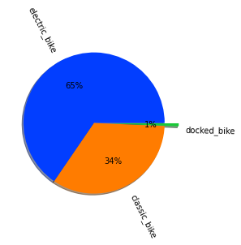

```python
# Which type of Ride is the most common?
Ride_type = df_2022.type_of_ride.value_counts()
explode = [0, 0, 0.2]

labels = ['electric_bike','classic_bike','docked_bike']

# Seaborn color palette to plot pie chart
colors = sb.color_palette('bright')

# create pie chart using matplotlib
plt.pie(Ride_type, labels=labels, colors=colors,
        autopct='%.0f%%', explode=explode, shadow=True, rotatelabels='true')
plt.show()
```

The electric bike was the most popular type of ride used in the first 3 months of 2022

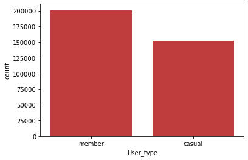

```python
# Which User type is more frequent?
base_color=sb.color_palette()[3]
sb.countplot(data= df_2022 ,x ='User_type',color = base_color);
```

Member rides were more than casual rides in the first 3 months of 2022

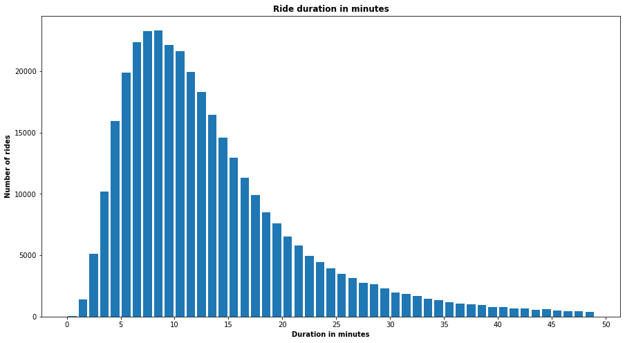

```python
# Most common time duration range for rides
plt.figure(figsize=[15,8])
bins=np.arange(0,50,1)
ticks = [0,5,10,15,20,25,30,35,40,45,50]
labels=['{}'.format(v) for v in ticks]

plt.hist(data=df_2022,x='duration_in_minutes',bins=bins,rwidth=0.8)
plt.title('Ride duration in minutes',y=1 ,fontweight = 'bold')
plt.xlabel('Duration in minutes',fontweight = 'bold')
plt.ylabel('Number of rides',fontweight = 'bold')
plt.xticks(ticks,labels);
```

The 5-10 minutes mark is the most common time duration for Rides

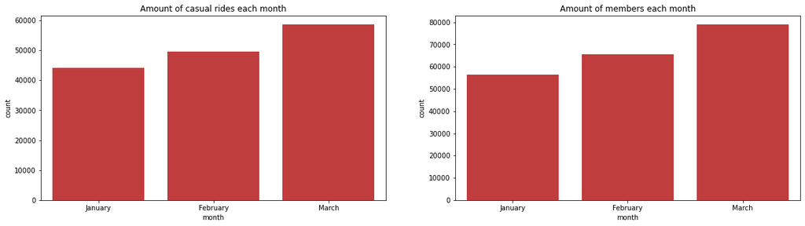

```python
# This set of bar charts give information on the amount of each user type for every month
plt.figure(figsize = [20, 5])

plt.subplot(1, 2, 1)
base_color=sb.color_palette()[3]
sb.countplot(data= df_2022.query('User_type == "casual"') ,x ='month',color = base_color);
plt.title('Amount of casual rides each month');


plt.subplot(1, 2, 2)
base_color=sb.color_palette()[3]
sb.countplot(data= df_2022.query('User_type == "member"') ,x ='month',color = base_color)
plt.title('Amount of members each month');
```

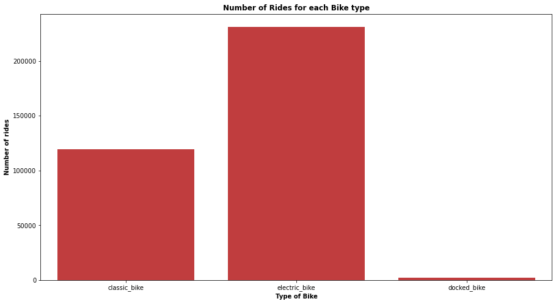

```python
# Which bike type was most frequently used?
plt.figure(figsize=[15,8])
base_color=sb.color_palette()[3]
sb.countplot(data= df_2022 ,x ='type_of_ride',color = base_color);
plt.title('Number of Rides for each Bike type',y=1 ,fontweight = 'bold')
plt.xlabel('Type of Bike',fontweight = 'bold')
plt.ylabel('Number of rides',fontweight = 'bold');
```

As illustrated previously in the pie chart, the electric bike is the most popular type of bike while the docked bike is the least popular

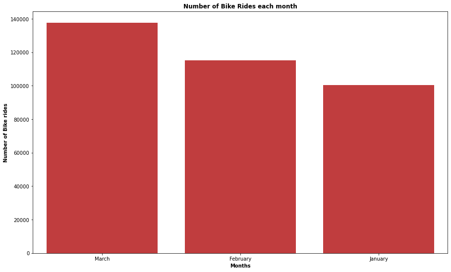

```python
# Which month has the highest number of rides?
months = df_2022.month.value_counts()
plt.figure(figsize=[15,9])
base_color = sb.color_palette()[3]
monthorder = df_2022.month.value_counts().index
sb.countplot(data = df_2022 , x = 'month' , color = base_color , order = monthorder);
plt.title('Number of Bike Rides each month',fontweight='bold',y=1);
plt.xlabel('Months',fontweight='bold');
plt.ylabel('Number of Bike rides',fontweight='bold');
```

From the bar chart above it can be noted that there is an Increase in the number of Rides as the months go by with march recording the largest number of rides while January being the least

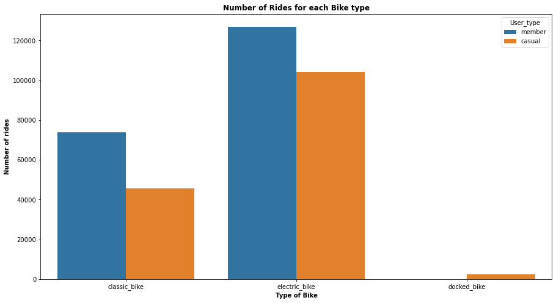

```python
# Which type of ride was the most popular among each User type?
plt.figure(figsize=[15,8])

sb.countplot(data= df_2022 ,x ='type_of_ride', hue='User_type');
plt.title('Number of Rides for each Bike type',y=1 ,fontweight = 'bold')
plt.xlabel('Type of Bike',fontweight = 'bold')
plt.ylabel('Number of rides',fontweight = 'bold');
```

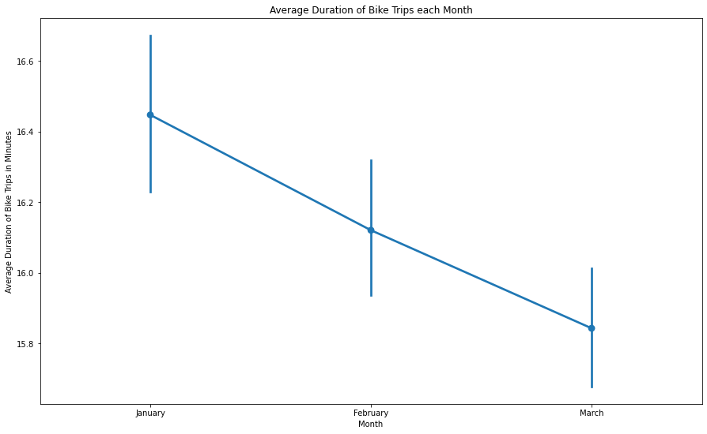

```python
# Which month had the longest ride time duration?
plt.figure(figsize=[15,9])
base_color=sb.color_palette()[3]
sb.pointplot(data = df_2022, x='month',y = 'duration_in_minutes', kind = 'Point')
plt.xlabel('Month')
plt.ylabel('Average Duration of Bike Trips in Minutes')
plt.title('Average Duration of Bike Trips each Month');
```

On Average, rides were the fastest in March and slowest in January .

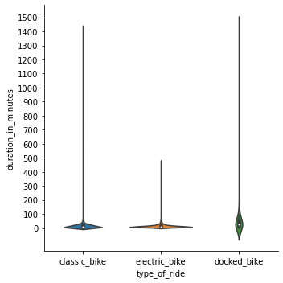

```python
plt.figure(figsize=[19,18])
ticks=[0,100,200,300,400,500,600,700,800,900,1000,1100,1200,1300,1400,1500]
labels=['{}'.format(v) for v in ticks]

sb.catplot(x='type_of_ride',kind='violin',y='duration_in_minutes',data=df_2022)
plt.yticks(ticks,labels);
```

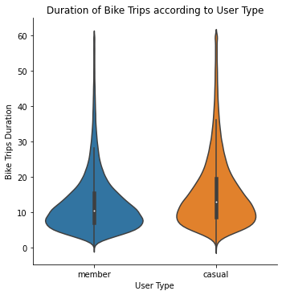

```python
# Among the 'short' rides which user type spent the longest time riding?
plt.figure(figsize=[19,18])

sb.catplot(x='User_type',kind='violin',y='duration_in_minutes',data=df_2022.query('duration_in_minutes <= 60'))
plt.title('Duration of Bike Trips according to User Type')
plt.xlabel('User Type')
plt.ylabel('Bike Trips Duration')
```

## Multivariate Exploration

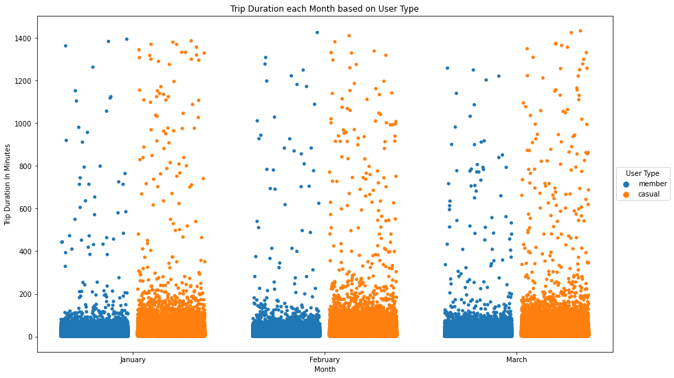

```python
plt.figure(figsize=[15,9])
sb.stripplot(data=df_2022,x = 'month',y='duration_in_minutes' , hue = 'User_type',jitter = 0.35,dodge = True)
plt.legend(loc = 'center left',bbox_to_anchor = (1,0.5),title = 'User Type')
plt.xlabel('Month')
plt.ylabel('Trip Duration In Minutes')
plt.title('Trip Duration each Month based on User Type');
```

When viewed by Month without a duration limit, the plot shows casual people had longer trip durations than members each month

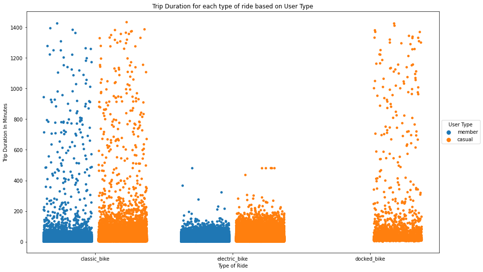

```python
plt.figure(figsize=[15,9])
sb.stripplot(data=df_2022,x = 'type_of_ride',y='duration_in_minutes' , hue = 'User_type',jitter = 0.35,dodge = True)
plt.legend(loc = 'center left',bbox_to_anchor = (1,0.5),title = 'User Type')
plt.xlabel('Type of Ride')
plt.ylabel('Trip Duration In Minutes')
plt.title('Trip Duration for each type of ride based on User Type');
```

This Stripplot shows the preference of the users and also the quickest ride The members dont make use of the docked bike while the electric bike takes the least time among all bike types

## Conclusions

The insights that stood out were;

- No member made use of the docked bike and there was a general preference for the electric bike
- March was the best month among the first 3 months of 2022 for the Baywheels bike sharing system and there was a gradual increase in the number of rides across the first 3 months hinting at increasing popularity

  - Which bike should be purchased if the Baywheels bike sharing system wants to expand its current capacity?
  - Is the method at which services is being carried out working? The Baywheels bike sharing system dataset was a very insightful one and the insights obtained will surely help the business make well informed decisions.